# Sampling Distributions Unveiled

```r
library(tidyverse)
library(dplyr)
library(pander)
```

## Sampling Distribution

What is a sampling distribution? A sampling distribution is the distribution of values for a given metric that we would obtain when selecting a subset of individuals from a population.

## The True Fake Law

Let’s establish a fictitious law to describe a natural phenomenon. Let’s suppose a law that governs how many women are interested in a relationship with a gentleman at any given time.

Here is the general equation for the line:

$\overbrace{y_i}^{\text{Dependent Variable}} = \overbrace{\beta_0}^{\text{Intercept}} + \overbrace{\beta_1}^{\text{Slope}} \overbrace{x_i}^{\text{Independent Variable}} + \overbrace{\epsilon_i}^{\text{Error Term}}$

Here is the equation with our chosen values:

$\overbrace{y_i}^{\text{Number of Women Interested}} = \overbrace{10}^{\text{Intercept}} + \overbrace{1}^{\text{Rate of Change}}\times \text{Income in \$1000} + \epsilon_i \sim N(0, 10)$

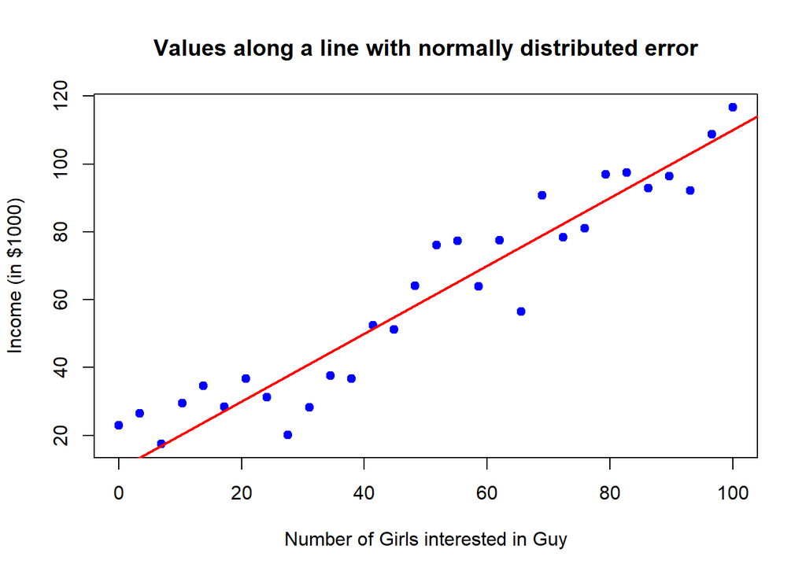

```r
#Law

# Parameters for the line
b1 <- 10      # Intercept
b2 <- 1    # Slope

# Generate x values in the desired range
x <- seq(0, 100, length.out = 30) # seq is range, length.out is number of points

# Compute y values without error
y <- b1 + b2 * x

# Generate normally distributed errors with mean 0 and standard deviation 10
error <- rnorm(length(x), mean = 0, sd = 10)

# Add error to the y values
y_with_error <- y + error

# Plot the results
plot(x, y_with_error, main = "Values along a line with normally distributed error",
     xlab = "Number of Girls interested in Guy", ylab = "Income (in $1000)", pch = 19, col = "blue")
abline(b1, b2, col = "red", lwd = 2)  # Plot the true line for reference
```

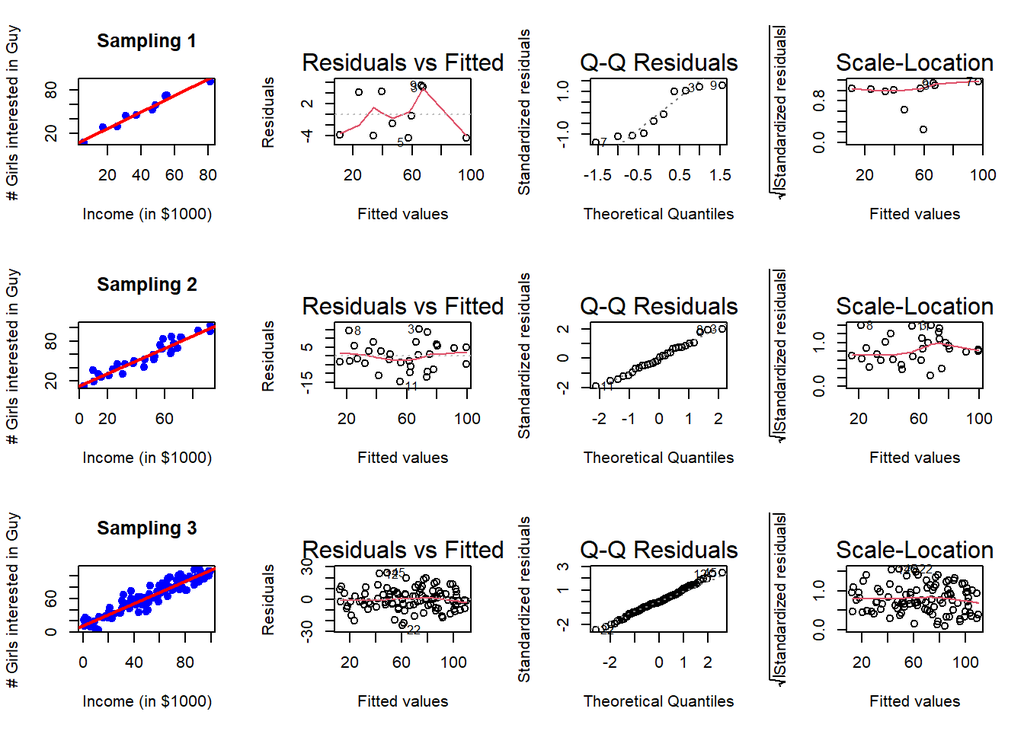

```r
b1 = 10
b2 = 1


par(mfrow = c(3, 4))

# First dataset
set.seed(100)

num_points <- 10

x <- random_points <- runif(num_points, min = 0, max = 100) # length.out is number
y <- b1 + b2 * x
error <- rnorm(length(x), mean = 0, sd = 10)
y_with_error <- y + error

lm1 <- lm(y_with_error ~ x)

# Scatter plot
plot(x, y_with_error, main = "Sampling 1",
     xlab = "Income (in $1000)", ylab = "# Girls interested in Guy", pch = 19, col = "blue")
abline(coef(lm1), col = "red", lwd = 2)  # Plot the fitted line

# Residual plots
plot(lm1, which = 1:3)

# Second dataset
set.seed(200)


num_points <- 30

x <- random_points <- runif(num_points, min = 0, max = 100)
y <- b1 + b2 * x
error <- rnorm(length(x), mean = 0, sd = 10)
y_with_error <- y + error

lm2 <- lm(y_with_error ~ x)

# Scatter plot
plot(x, y_with_error, main = "Sampling 2",
     xlab = "Income (in $1000)", ylab = "# Girls interested in Guy", pch = 19, col = "blue")
abline(coef(lm2), col = "red", lwd = 2)  # Plot the fitted line

# Residual plots
plot(lm2, which = 1:3)

# Third dataset

set.seed(300)

num_points <- 100

x <- random_points <- runif(num_points, min = 0, max = 100)
y <- b1 + b2 * x
error <- rnorm(length(x), mean = 0, sd = 10)
y_with_error <- y + error

lm3 <- lm(y_with_error ~ x)

# Scatter plot
plot(x, y_with_error, main = "Sampling 3",
     xlab = "Income (in $1000)", ylab = "# Girls interested in Guy", pch = 19, col = "blue")
abline(coef(lm3), col = "red", lwd = 2)  # Plot the fitted line

# Residual plots
plot(lm3, which = 1:3)
```

```r
# Summaries
print("Sampling 1")
```

```
## [1] "Sampling 1"
```

```r
pander(summary(lm1))
```

|  | Estimate | Std. Error | t value | Pr(>\|t\|) |
| --- | --- | --- | --- | --- |
| **(Intercept)** | 4.888 | 3.156 | 1.549 | 0.16 |
| **x** | 1.13 | 0.06974 | 16.2 | 2.119e-07 |

Fitting linear model: y_with_error ~ x

| Observations | Residual Std. Error | $R^2$ | Adjusted $R^2$ |
| --- | --- | --- | --- |
| 10 | 4.557 | 0.9704 | 0.9667 |

```r
print("Sampling 2")
```

```
## [1] "Sampling 2"
```

```r
pander(summary(lm2))
```

|  | Estimate | Std. Error | t value | Pr(>\|t\|) |
| --- | --- | --- | --- | --- |
| **(Intercept)** | 12.73 | 3.168 | 4.017 | 0.0004011 |
| **x** | 0.9386 | 0.05921 | 15.85 | 1.631e-15 |

Fitting linear model: y_with_error ~ x

| Observations | Residual Std. Error | $R^2$ | Adjusted $R^2$ |
| --- | --- | --- | --- |
| 30 | 7.966 | 0.8997 | 0.8961 |

```r
print("Sampling 3")
```

```
## [1] "Sampling 3"
```

```r
pander(summary(lm3))
```

|  | Estimate | Std. Error | t value | Pr(>\|t\|) |
| --- | --- | --- | --- | --- |
| **(Intercept)** | 11.65 | 2.279 | 5.11 | 1.59e-06 |
| **x** | 0.9886 | 0.03666 | 26.97 | 3.862e-47 |

Fitting linear model: y_with_error ~ x

| Observations | Residual Std. Error | $R^2$ | Adjusted $R^2$ |
| --- | --- | --- | --- |
| 100 | 9.965 | 0.8813 | 0.8801 |

We can see how even though these are all obtained for samples from the same simulated population, or equation, the regression models and goodness of fit charts vary.

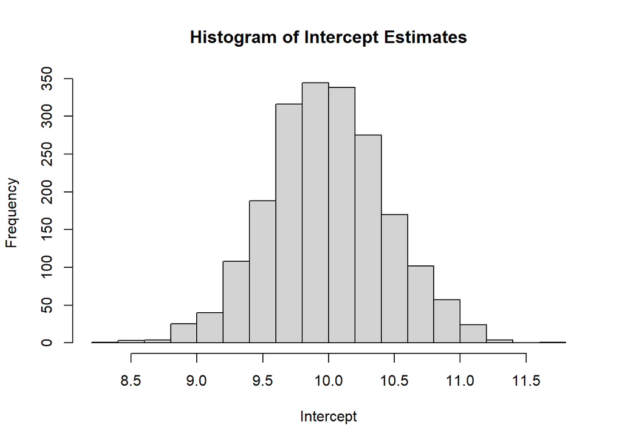

```r
set.seed(100)

b1 <- 10
b2 <- 1

n <- 2000
intercepts <- numeric(n)
slopes <- numeric(n)

for (i in 1:n) {
  Xi <- rep(seq(0, 100, length.out = n/2), each = 2) # n must be even.
  Yi <- b1 + b2 * Xi + rnorm(length(Xi), 0, 10)

  mylm <- lm(Yi ~ Xi)
  intercepts[i] <- coef(mylm)[1] # intercept only
  slopes[i] <- coef(mylm)[2] # slope only
}

hist(intercepts, main = "Histogram of Intercept Estimates", xlab = "Intercept",breaks=20)
```

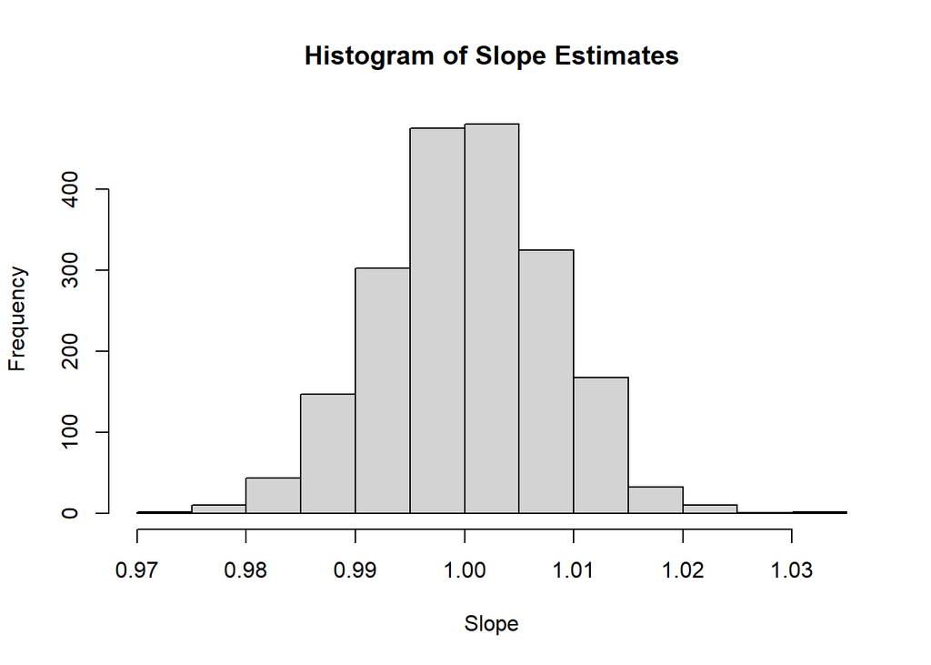

```r
hist(slopes, main = "Histogram of Slope Estimates", xlab = "Slope",breaks=20)
```

```r
intercepts_mean <- mean(intercepts)
intercepts_sd <- sd(intercepts)
slopes_mean <- mean(slopes)
slopes_sd <- sd(slopes)

# Create a data frame
summary_table <- data.frame(
  Variable = c("Intercepts", "Slopes"),
  Mean = c(intercepts_mean, slopes_mean),
  SD = c(intercepts_sd, slopes_sd)
)

pander(summary_table)
```

| Variable | Mean | SD |
| --- | --- | --- |
| Intercepts | 9.994 | 0.4533 |
| Slopes | 1 | 0.007892 |

This shows that without knowing the ‘true line’, with a large enough sample size, our estimate will be almost nearly exact.

## P Values

```r
print("Sampling 2")
```

```
## [1] "Sampling 2"
```

```r
pander(summary(lm2))
```

|  | Estimate | Std. Error | t value | Pr(>\|t\|) |
| --- | --- | --- | --- | --- |
| **(Intercept)** | 12.73 | 3.168 | 4.017 | 0.0004011 |
| **x** | 0.9386 | 0.05921 | 15.85 | 1.631e-15 |

Fitting linear model: y_with_error ~ x

| Observations | Residual Std. Error | $R^2$ | Adjusted $R^2$ |
| --- | --- | --- | --- |
| 30 | 7.966 | 0.8997 | 0.8961 |

This works because we can use the t-distribution at 28 degrees, scale it based off of the value of the intercept or slope, and by find the points at which other slope and intercept values have a 95% probability of being between those points.

the logic of the p value is that there is are probabilities of values landing within certain ranges on the sampling distribution, so samples found at a point above or certain places have a certain chance of occurring. If we have a very small p value (which we do in this case, of .0004 for the intercept, and smaller for the slope) it means that the probability of getting that value by chance is very low, which can be a measure of validity.

```r
# Slope t value
t_value <- 4.017
value <- pt(t_value,28)
print(value)
```

```
## [1] 0.9997993
```

```r
one_side = 1-value
two_side = one_side * 2
print(two_side) # value is one side, multiply by 2 to get actual value
```

```
## [1] 0.0004014767
```

```r
# I could have used lower.tail = FALSE but what fun is that?
```

## Confidence Intervals.

We can use the standard errors for both the intercept and slope estimate to estimate the confidence interval.

```r
t_value <- qt(0.975, df = 30 - 2) # 30 samples, - 2 = 28

# Calculate confidence interval for the intercept
ci_intercept <- 12.73 + c(-1, 1) * t_value * 3.168

# Calculate confidence interval for the slope
ci_slope <- .9386 + c(-1, 1) * t_value * .05921

print("95% confidence intervals for slope and intercept:")
```

```
## [1] "95% confidence intervals for slope and intercept:"
```

```r
print(ci_intercept)
```

```
## [1]  6.240646 19.219354
```

```r
print(ci_slope)
```

```
## [1] 0.8173138 1.0598862
```